# Projekt: Wykroczenia w Krakowie

## Biblioteki

```r
library(spatstat)
library(dbscan)
library(tidyverse)
library(raster)
```

```r
library(ggplot2)
library(sp)
```

## Preprocessing

### Zmiana projekcji i zapisanie danych

```r
data <- read.csv2("./dane/zestaw4.csv", colClasses = c("numeric", "numeric"))
colnames(data) <- c("Lon", "Lat")

coord <- SpatialPoints(cbind(data$Lon, data$Lat), proj4string = CRS("+proj=longlat"))

coordUTM <- spTransform(coord, CRS("+init=epsg:2178"))
dataUTM <- data.frame(coordUTM)
colnames(dataUTM) <- c("Lon", "Lat")
write.csv2(dataUTM, "zeszyt4_edit.csv", row.names = F)
```

### Wczytanie danych

```r
zeszyt4 <- read.csv2("./zeszyt4_edit.csv")
osiedla <- shapefile("./dane/osiedla.shp")
```

## ALGORYTMY:

DBSCAN - algorytm grupowania gęstościowego, algorytm identyfikuje rdzenie klastrów jako punkty w sąsiedztwie których znajduje się co najmniej tyle punktów ile wynosi wartość graniczna

Zalety:

- Radzi sobie z wartościami odstającymi i szumem

Wady:

- Wrażliwy na parametry gęstości
- Słabo radzi sobie przy zmiennej gęstości

HDBSCAN - rozwinięcie DBSCAN, do zdefiniowanych rdzeni dolączane są punkty pozostające w bliskiej odleglości od któregokolwiek z punktów rdzenia, które w sumie tworzą klaster.

Zalety:

- Działa lepiej od DBSCAN przy danych o zmiennej gęstości

Wady:

- Przez wysoką złożoność operacji HDBSCAN jest trudniejszy w analizie

OPTICS - algorytm grupowania gęstościowego podobny do DBSCAN, ale mający nad nim przewagę że lepiej wykrywa klastry w danych o różnej gęstości

Zalety:

- Nie wymaga parametrów gęstości

Wady:

- Tworzy tylko kolejność klastrów
- Nie radzi sobie z wielowymiarowymi danymi

## MAPA

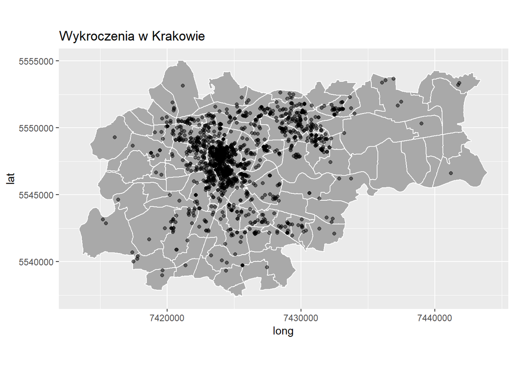

```r
map <- ggplot() +
  geom_polygon(data=osiedla, aes(x=long, y=lat, group=group), show.legend = F, color="white", fill="darkgrey") + coord_fixed() + ggtitle("Wykroczenia w Krakowie")
map + geom_point(data=zeszyt4, aes(x=Lon, y=Lat), alpha=0.5)
```

## DBSCAN

#### Parametry: eps=10, minPts=10

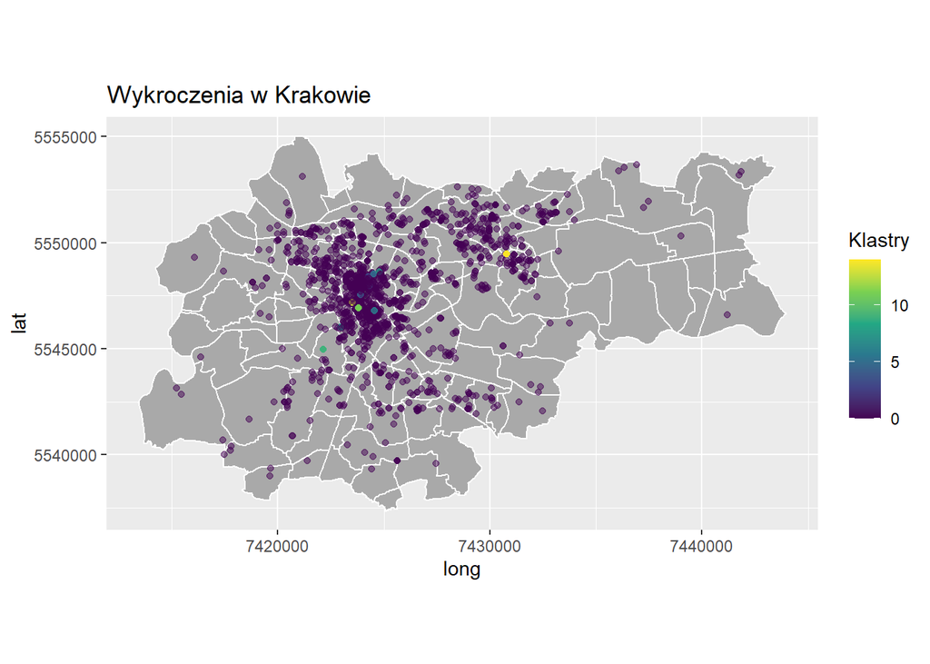

```r
dbscan_res1 <- dbscan(zeszyt4, eps=10, minPts = 10)
map + geom_point(data=zeszyt4, aes(x=Lon, y=Lat, color = dbscan_res1$cluster), alpha=0.5) + scale_color_viridis_c(name="Klastry")
```

Przy eps=10 klastrow jest niewiele

#### Parametry: eps=50, minPts=10

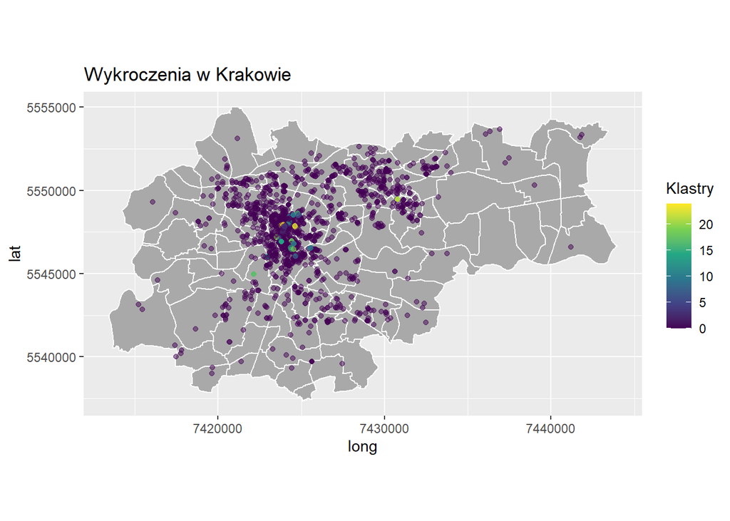

```r
dbscan_res2 <- dbscan(zeszyt4, eps=50, minPts = 10)
map + geom_point(data=zeszyt4, aes(x=Lon, y=Lat, color = dbscan_res2$cluster), alpha=0.5) + scale_color_viridis_c(name="Klastry")
```

Przy esp=50 zaczynaja pojawiać się klastry w okolicach centrum

#### Parametry: eps=200, minPts=10

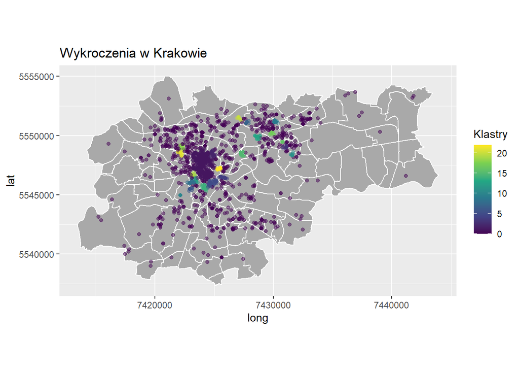

```r
dbscan_res3 <- dbscan(zeszyt4, eps=200, minPts = 10)
map + geom_point(data=zeszyt4, aes(x=Lon, y=Lat, color = dbscan_res3$cluster), alpha=0.5) + scale_color_viridis_c(name="Klastry")
```

Przy esp=200 w centrum i okolicach Mistrzejowic widać wiele klastrów

## HDBSCAN

#### Parametry: minPoints=10

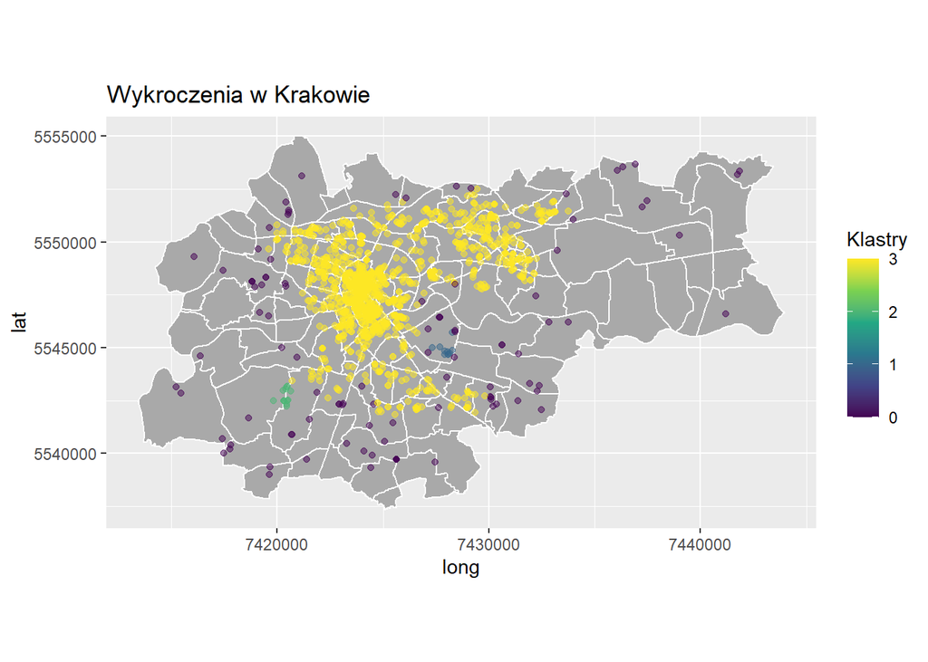

```r
hdbscan_res1 <- hdbscan(zeszyt4, minPts = 10)
map + geom_point(data=zeszyt4, aes(x=Lon, y=Lat, color = hdbscan_res1$cluster), alpha=0.5) + scale_color_viridis_c(name="Klastry")
```

Przy minPoints=10 widac jedynie 3 klastry, widac ze intensywnosc wykroczen dominuje w centrum miasta

#### Parametry: minPoints=50

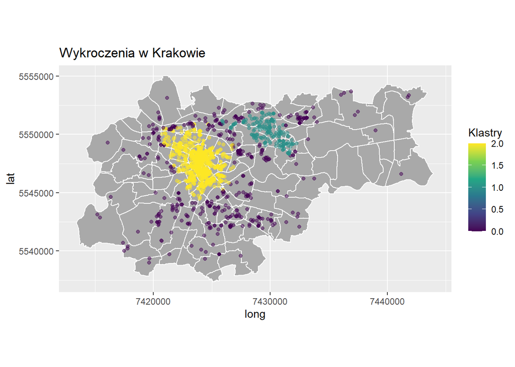

```r
hdbscan_res2 <- hdbscan(zeszyt4, minPts = 50)
map + geom_point(data=zeszyt4, aes(x=Lon, y=Lat, color = hdbscan_res2$cluster), alpha=0.5) + scale_color_viridis_c(name="Klastry")
```

Przy minPts=50, tak jak wyszlo przy dbscan dominuja Centrum i Mistrzejowice

#### Parametry: minPts = 100

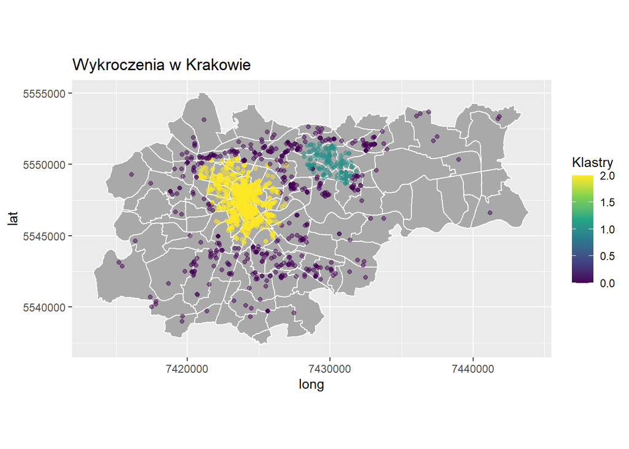

```r
hdbscan_res3 <- hdbscan(zeszyt4, minPts = 100)
map + geom_point(data=zeszyt4, aes(x=Lon, y=Lat, color = hdbscan_res3$cluster), alpha=0.5) + scale_color_viridis_c(name="Klastry")
```

Przy minPts=100 roznice sa niewielkie wzgledem minPts=50

## OPTICS

### Parametry: minPts=10, eps_cl=1

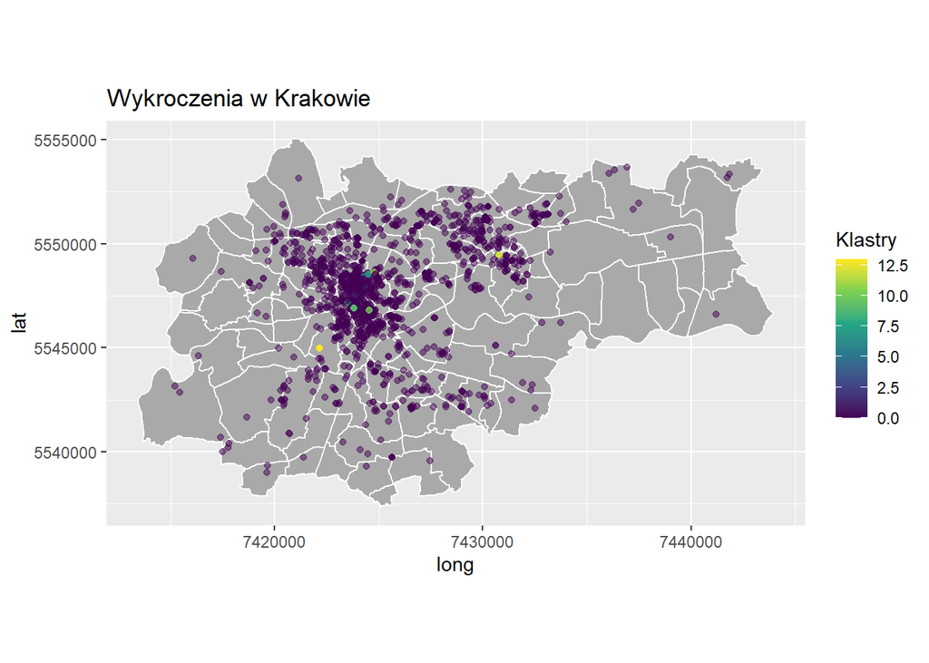

```r
optics_res1 <- optics(zeszyt4, minPts = 10)
optics_cl1 <- extractDBSCAN(optics_res1, eps_cl=1)
map + geom_point(data=zeszyt4, aes(x=Lon, y=Lat, color = optics_cl1$cluster), alpha=0.5) + scale_color_viridis_c(name="Klastry")
```

#### Parametry: minPts=10, eps_cl=500

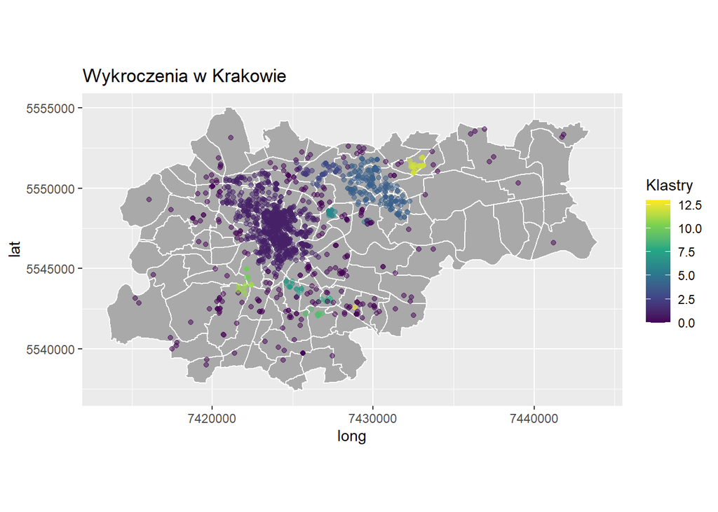

```r
optics_res2 <- optics(zeszyt4, minPts = 10)
optics_cl2 <- extractDBSCAN(optics_res2, eps_cl=500)
map + geom_point(data=zeszyt4, aes(x=Lon, y=Lat, color = optics_cl2$cluster), alpha=0.5) + scale_color_viridis_c(name="Klastry")
```

Widac klastry w okolicach Centrum, Mistrzejowic oraz okolic Kurdwanowa

#### Parametry: minPts=10, eps_cl=700

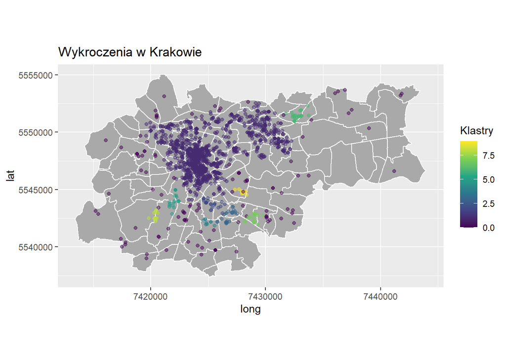

```r
optics_res3 <- optics(zeszyt4, minPts = 10)
optics_cl3 <- extractDBSCAN(optics_res3, eps_cl=700)
map + geom_point(data=zeszyt4, aes(x=Lon, y=Lat, color = optics_cl3$cluster), alpha=0.5) + scale_color_viridis_c(name="Klastry")
```

## Wnioski:

Na podstawie użytych algorytmów możemy stwierdzić że najlepszym działaniem wykazał się OPTICS z parametrami minPts=10 i eps_cl=500, ponieważ dane mają mocno zróżnicowaną intensywność. OPTICS wydzielił 2 większe klastry w Centrum i okolicach Mistrzejowic, a także kilka mniejszych w okolicach Woli Duchackiej, Łagiewnik i Ruczaju.